BLOQUE 4 DE 6

Cuánta información conservamos

Reconstruir, medir el error y decidir cuántas componentes.

# Reconstruir un dato desde sus componentes

Si los scores se armaron combinando las variables, se puede hacer el **camino inverso**:

Usá **→** para ir revelando los términos.

Por qué importa

Con $M$ componentes, esta es la mejor aproximación posible en $M$ dimensiones. Ninguna otra combinación lineal reconstruye mejor. Eso es lo que hace de PCA una técnica de **compresión**, no un resumen más.

# El error cae rápido: pocas componentes bastan

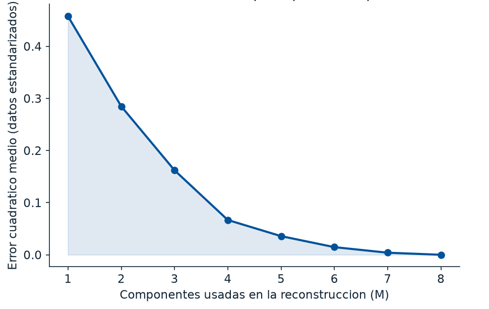

Error cuadrático medio al reconstruir las ocho variables de los 4.424 estudiantes. Con **1** componente es 0,46; con **4** baja a 0,07; con las **8** es exactamente cero: usar todas es solo rotar los ejes.

# La varianza total se reparte entre las componentes

- Con variables **estandarizadas**, cada una aporta 1 unidad de varianza: la varianza total es exactamente $p$ (acá, **8**).
- Cada componente explica una porción de ese total: su **autovalor**.
- La **PVE** de una componente es esa porción sobre el total. Sumando todas, siempre da 100%.

| Componente | 1 | 2 | 3 | 4 | 5 | 6 | 7 | 8 |
| --- | --- | --- | --- | --- | --- | --- | --- | --- |
| PVE (%) | 54,2 | 17,3 | 12,3 | 9,5 | 3,1 | 2,1 | 1,1 | 0,4 |
| Acumulada (%) | 54,2 | 71,5 | 83,8 | 93,3 | 96,4 | 98,5 | 99,6 | 100 |

# El scree plot y el criterio del codo

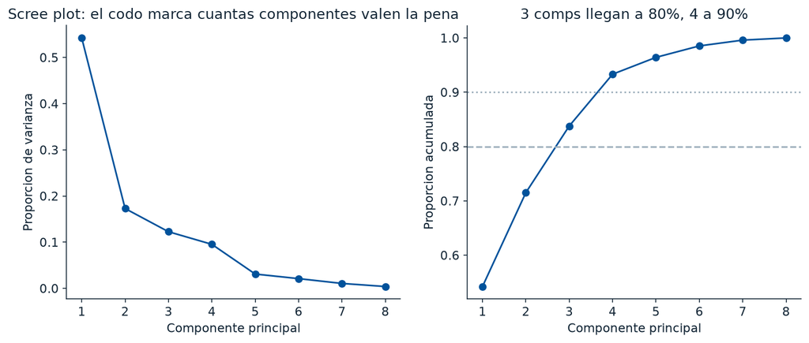

Se busca el **codo**: el punto donde cada componente adicional deja de aportar. Acá, 3 componentes llegan al 80% de la varianza y 4 superan el 90%.

# La PVE es el $R^2$ de la aproximación

Un gancho con lo que ya saben

La proporción de varianza explicada por las primeras $M$ componentes se interpreta **exactamente** como el $R^2$ de la regresión lineal: qué fracción de la variabilidad total se logra explicar.

# Máxima varianza y mínimo error son lo mismo

- La varianza total de los datos se reparte en **dos partes**: lo que capturan las primeras $M$ componentes, más el **error** de reconstruirlos con esas $M$.
- Como la varianza total es un número **fijo**, subir una es bajar la otra.

La equivalencia, cerrada

**Maximizar** la varianza explicada por las primeras $M$ componentes es exactamente lo mismo que **minimizar** el error de reconstrucción.

Es la razón por la que las dos definiciones del Bloque 2, máxima varianza y mínima distancia, describen el mismo objeto.

# Cuántas retener: no hay respuesta única

- No existe un criterio objetivo y universal. En análisis no supervisado, la decisión es en parte un **juicio**.
- Se mira el **codo** del scree plot, o se fija un umbral de varianza acumulada (80% o 90%).
- Regla práctica: si las primeras componentes no muestran nada interesante, las siguientes tampoco suelen hacerlo.

Cuando sí hay criterio objetivo

Si las componentes se usan como **predictores** de un modelo posterior, el número se elige como cualquier hiperparámetro: por **validación cruzada**.

[figure not shown]

A la notebook

Reconstruir un dato con 1, 2 y todas las componentes, y ver caer el error.

**Ejercicio:** cuántas componentes hacen falta para llegar al 90%.